# TSVR

The following dataset used in the analysis counts with a variable number for participants (ptcp), a variable number for the ‘set,’ which refers to one of the three chunks of uninterrupted trails and a variable called level (‘lvl’) assigned each of the 36-trials presented per set.

The variable ‘start’ corresponds to the moment the ball is placed in the hand of the participant. The number represents the row position in the original raw data. Likewise, ‘end’ corresponds to the explosion of the board and it also represents a row position in the original raw data.

The variable ‘accuracy’ takes value 1 when there is a mistake 0 otherwise.

The variable ‘diff’ refers to the time difference between ‘start’ and ‘end’, expressed in seconds and to finalize the categorical variable ‘stimulus’ signals whether the participant felt the vibration on the same hand the see the ball placed or not.

There are some trails being left out due to participants taking longer than 6 seconds to answer, when placed the ball not being recognized, or if there was a ezPlotdata glove failure.

```r
summary(tsvr)
```

```
##       set             lvl             end             start
##  Min.   :1.000   Min.   : 0.00   Min.   :  2255   Min.   :  1824
##  1st Qu.:1.000   1st Qu.: 8.00   1st Qu.: 86449   1st Qu.: 85961
##  Median :2.000   Median :17.00   Median :161965   Median :161529
##  Mean   :2.028   Mean   :17.14   Mean   :164016   Mean   :163526
##  3rd Qu.:3.000   3rd Qu.:26.00   3rd Qu.:239471   3rd Qu.:238952
##  Max.   :3.000   Max.   :34.00   Max.   :391406   Max.   :390966
##
##       diff              stimulus        ptcp         accuracy
##  Min.   :3.120   base       :644   1      : 103   Min.   :0.00000
##  1st Qu.:3.256   Incongruent:624   14     : 102   1st Qu.:0.00000
##  Median :3.406   Congruent  :632   13     : 101   Median :0.00000
##  Mean   :3.685                     2      : 100   Mean   :0.05789
##  3rd Qu.:3.947                     15     : 100   3rd Qu.:0.00000
##  Max.   :5.992                     19     :  99   Max.   :1.00000
##                                    (Other):1295
```

**1. Testing time difference between conditions withing subjects (base, congruent, incongruent).**

a.- With the aggregated data, partially cleaned, we run an ANOVA to test for response time difference between stimuli groups. I was not familiar with this package, which Esra suggested and it runs easily within subjects ANOVAS. The results show significant difference between groups:

*diff is not a normally distributed variable, ANOVA can handle this*

```r
output_anova = ezANOVA(data = tsvr,
        dv = .(diff),
        wid = .(ptcp),
        within = .(stimulus),
        within_covariates = .(set),
        detailed = T,
        type=3)

print(output_anova)
```

```
## $ANOVA
##        Effect DFn DFd          SSn       SSd          F            p p<.05
## 1 (Intercept)   1  19 819.35168327 5.1241179 3038.11937 1.975911e-22     *
## 2    stimulus   2  38   0.03391629 0.1971811    3.26811 4.901564e-02     *
##          ges
## 1 0.99354738
## 2 0.00633332
##
## $`Mauchly's Test for Sphericity`
##     Effect         W         p p<.05
## 2 stimulus 0.9277851 0.5093619
##
## $`Sphericity Corrections`
##     Effect       GGe      p[GG] p[GG]<.05      HFe      p[HF] p[HF]<.05
## 2 stimulus 0.9326488 0.05296868           1.030247 0.04901564         *
```

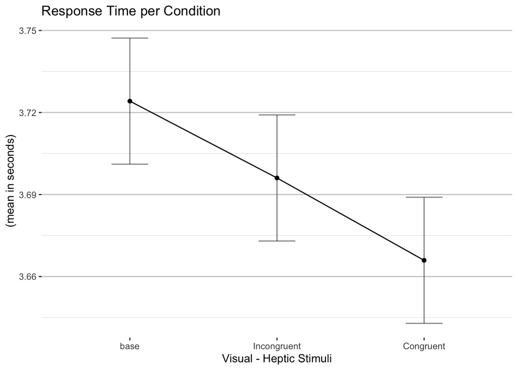

**2. Testing for accuracy difference between conditions withing subjects (base, congruent, incongruent).**

a.- We are to consider whether congruent, incongruent and base conditions play any significant roll on the mistake’s behaviour shown by participants when placing the ball on the memorised spot.

Since we have defined the variable as binary dependant one (0 if correct 1 if incorrect) we run linear mixed effect model using the participants variable as random effects.

```
## Linear mixed model fit by REML. t-tests use Satterthwaite's method [
## lmerModLmerTest]
## Formula: accuracy ~ stimulus + (1 | ptcp)
##    Data: tsvr
##
## REML criterion at convergence: -136.2
##
## Scaled residuals:
##     Min      1Q  Median      3Q     Max
## -0.6934 -0.3025 -0.2069 -0.1392  4.2432
##
## Random effects:
##  Groups   Name        Variance Std.Dev.
##  ptcp     (Intercept) 0.001526 0.03906
##  Residual             0.053236 0.23073
## Number of obs: 1900, groups:  ptcp, 20
##
## Fixed effects:
##                       Estimate Std. Error         df t value Pr(>|t|)
## (Intercept)          6.000e-02  1.262e-02  4.264e+01   4.755 2.29e-05 ***
## stimulusIncongruent -2.627e-03  1.298e-02  1.881e+03  -0.202    0.840
## stimulusCongruent   -6.823e-04  1.293e-02  1.879e+03  -0.053    0.958
## ---
## Signif. codes:  0 '***' 0.001 '**' 0.01 '*' 0.05 '.' 0.1 ' ' 1
##
## Correlation of Fixed Effects:
##             (Intr) stmlsI
## stmlsIncngr -0.506
## stmlsCngrnt -0.508  0.494
```

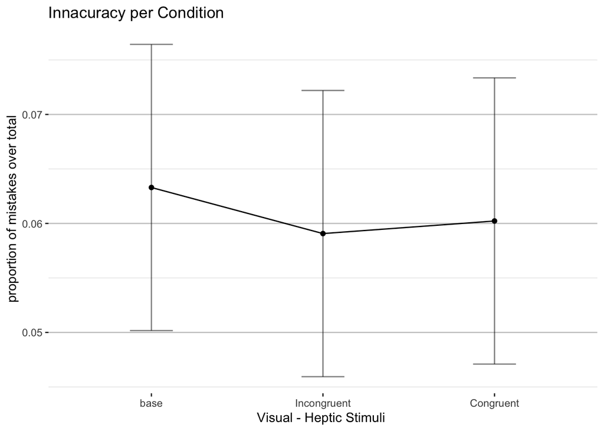

**3. Testing for IBI difference between conditions withing subjects (base, congruent, incongruent).**

a.- Inter beat intervals where detected using Hooman Sedghamiz (2018) algrithm. I consider the two seconds after the vibrations starts. The analysis was run without getting into detail of artifact removal.The removal of IBI where done using ‘rmoutliers’ MATLAB function.

At this point there were no significant difference between beat intervals.

```
## $ANOVA
##        Effect DFn DFd          SSn         SSd           F            p
## 1 (Intercept)   1  15 2.940031e+01 0.459848306 959.0220688 5.200574e-15
## 2    stimulus   2  30 2.908469e-05 0.002686637   0.1623853 8.508558e-01
##   p<.05          ges
## 1     * 9.845114e-01
## 2       6.287711e-05
##
## $`Mauchly's Test for Sphericity`
##     Effect         W         p p<.05
## 2 stimulus 0.7226144 0.1028837
##
## $`Sphericity Corrections`
##     Effect      GGe     p[GG] p[GG]<.05       HFe     p[HF] p[HF]<.05
## 2 stimulus 0.782849 0.7990204           0.8579221 0.8190892
```

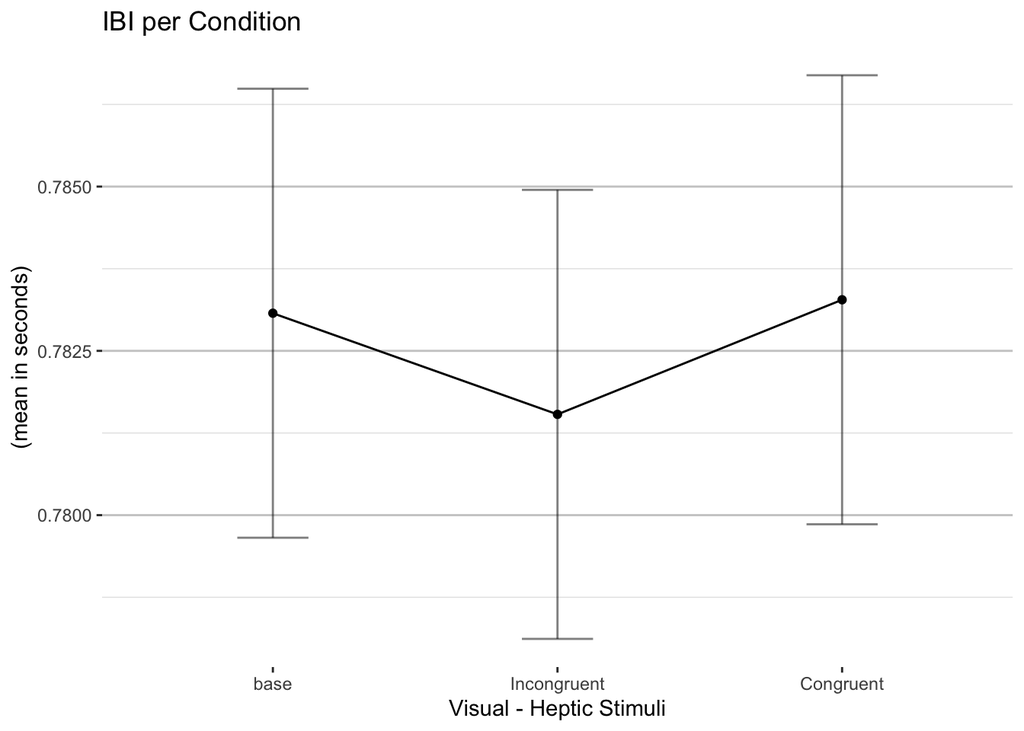

**4. Discussion**